# communityDiv - jamie

Jamie

April 20, 2019

```r
# import libraries
library(dplyr)
library(ggplot2)
library(ape)
library(ggtree)
library(vegan)
```

```r
# import data from 2014 and 2015
myData <- read.csv('./DryadData.csv')
myData2015 <- read.csv('./DryadData2015.csv')
```

# How does EFN density influence species diversity?

### Prepare data and calcuate species diversity

```r
## categorize EFN values into 'low' (<23), 'medium' (23-34), or 'high' (>34) for all individuals

    # values measured in number of EFNs per 11 leaves
sppData <- myData

sppData$EFNcat <- cut(sppData$TotEFN2014,
                     breaks = c(-Inf, 23, 34, Inf),
                     labels = c('Low', 'Medium', 'High'))

# remove rows with NA values
sppData <- sppData[!is.na(sppData$EFNcat),]
sppData <- sppData[!is.na(sppData$Phyllocolpa),]
```

```r
# isolate all species (from 2014 data)
sppDiv <- select(sppData, Harmandia, Phyllocolpa, PetioleGall, LeafEdgeMine,
                 SerpMine,
                 BlotchMine,
                 LombardyMine,
                 Gluphisia,
                 GreenNematus,
                 RustylinedLeaftier,
                 ObliqueBandedLeafRoller,
                 SmokeyAphids,
                 GreenAphids,
                 Lasius_neoniger)

# convert to binary (presence/absence of the species)
sppDivB <- sppDiv

sppDivB[sppDivB > 0] <- 1
```

### Investigate the relationship between EFN density and species diversity

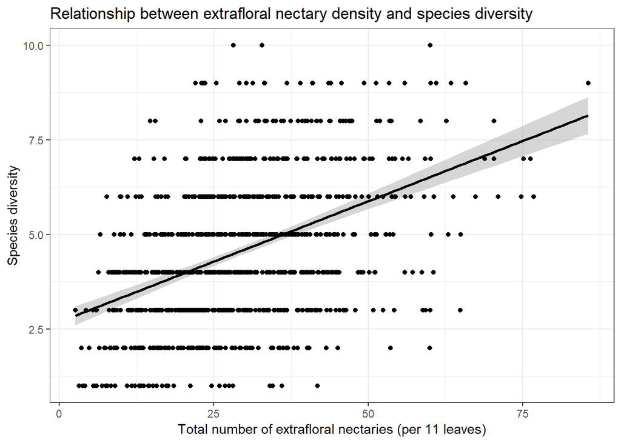

```r
# incorporate species diversity into sppData (value is number of species observed on the individual)
sppData$divTot <- rowSums(sppDivB)

# model of the effect of total EFN number per 11 leaves (TotEFN2014) and average tree size (AvgSize2014) in species diversity (divTot)
  # Average size included to disentangl effect of size on EFN density

sppDivMod <- lm(divTot ~ TotEFN2014 * AvgSize2014, data = sppData)

ggplot(data = sppData, aes(x = TotEFN2014, y = divTot)) +
  stat_smooth(method = 'lm', colour = 'black') +
  xlab('Total number of extrafloral nectaries (per 11 leaves)') +
  ylab('Species diversity') +
  ggtitle('Relationship between extrafloral nectary density and species diversity') +
  geom_point() +
  theme_bw()
```

### Construct a neighbor-joining tree

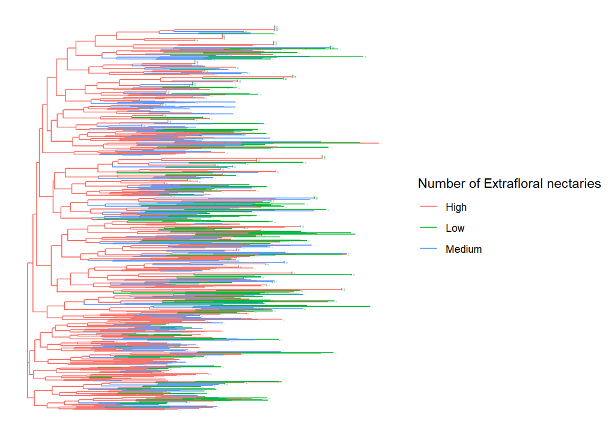

```r
# calculate binary distance matrix and neighbor-joining tree
sppDiv_distB <- dist(sppDivB, method = 'binary')

sppDiv_tree <- nj(sppDiv_distB)

# append tip labels and EFN category to tree data
EFNs <- sppData$EFNcat
EFNblocks <- split(sppDiv_tree$tip.label, EFNs)

sppDiv_ANtree <- groupOTU(sppDiv_tree, EFNblocks)

# visualize tree
ggtree(sppDiv_ANtree, layout = 'rectangular', aes(color = group)) +
  scale_colour_discrete(guides(name="Number of Extrafloral nectaries")) +
  geom_tiplab(size=0.3) +
  theme(legend.position = 'right')
```

Figure 2. A binary neighbor-joining tree of distance between insect species communities among *Populus tremuloides* individuals in the WispAsp common garden (2014). Genotypes are separated by high (red), medium (blue), and low (green) densities of extrafloral nectaries.

```r
sppDiv_dist <- vegdist(sppDiv, method = 'bray')

#Tnmds <- metaMDS(TsppDiv_dist2, k=4, trymax = 400)

#sppDivDF <- data.frame(NMDS1 = Tnmds$points[,1], NMDS2 = Tnmds$points[,2],
 #                  Individual = row.names(sppData),
#                   EFNdensity = sppData$EFNcat)

#ggplot(data = sppDivDF, aes(x = NMDS1, y = NMDS2, colour = EFNdensity), alpha = I(0.6)) +
#  geom_point() +
#  theme_bw()
```

# How does EFN density influence family diversity?

```r
# prepare data (as per previous calculations)
famData <- myData

famData$EFNcat <- cut(famData$TotEFN2014,
                       breaks = c(-Inf, 23, 34, Inf),
                       labels = c('Low', 'Middle', 'High'))

famData <- famData[!is.na(famData$EFNcat),]
famData <- famData[!is.na(famData$Phyllocolpa),]
```

### Construct a neighbor-joining tree

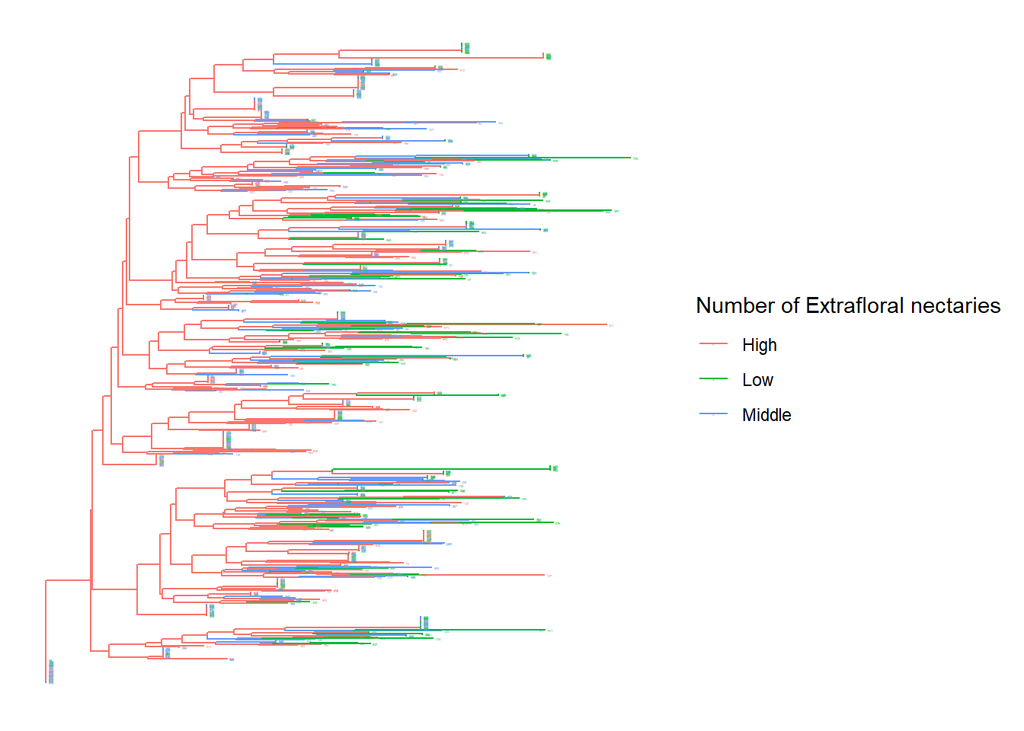

```r
# isolate families - determine binary diversity
famDiv <- select(famData, Cecidomyiidae, Tenthredinidae, Nepticulidae, Gracilliaridae,
                  Agromyzidae,
                  Notodontidae,
                  Tortricidae,
                  Aphididae,
                  Formicidae,
                  Chrysomelidae,
                  Pentatomidae,
                  Membracidae)

famDivB <- famDiv
famDivB[famDivB > 0] <- 1

# distance matrix and neighbor-joining tree
famDiv_distB <- dist(famDivB, method = 'binary')

famDiv_tree <- nj(famDiv_distB)

# prepare, annotate, and visualize NJ tree
EFNcat <- famData$EFNcat
EFNbins <- split(famDiv_tree$tip.label, EFNcat)

famDiv_ANtree <- groupOTU(famDiv_tree, EFNbins)

ggtree(famDiv_ANtree, layout = 'rectangular', aes(color = group, branch.length="none")) +
  scale_colour_discrete(guides(name="Number of Extrafloral nectaries")) +
  geom_tiplab(size=0.5) +
  theme(legend.position = 'right')
```

Figure 4. A binary neighbor-joining tree of distance between insect families among *Populus tremuloides* individuals in the WispAsp common garden (2014). Genotypes are separated by high (red), medium (blue), and low (green) densities of extrafloral nectaries.

### For family diversity, calculate Bray-Curtis and NMDS, again grouping by EFN density

```r
famDiv_dist <- vegdist(famDiv, method = 'bray')

Fnmds <- metaMDS(famDiv_dist, k=4, trymax = 400)
```

```
## *** No convergence -- monoMDS stopping criteria:
##    264: no. of iterations >= maxit
##    135: stress ratio > sratmax
##      1: scale factor of the gradient < sfgrmin
```

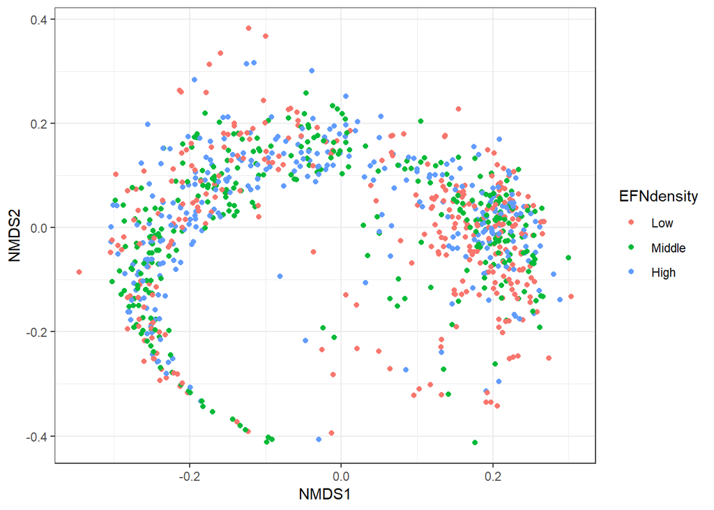

```r
famDivDF <- data.frame(NMDS1 = Fnmds$points[,1], NMDS2 = Fnmds$points[,2],
               Individual = row.names(famData),
               EFNdensity = famData$EFNcat)

ggplot(data = famDivDF, aes(x = NMDS1, y = NMDS2, colour = EFNdensity), alpha = I(0.6)) +
  geom_point() +
  theme_bw()
```

Figure 5. An NMDS plot of insect family communities among *Populus tremuloides* individuals within the WispAsp common garden (2014). Gneotypes are clustered by Bray-Curtis dissimilarity and coloured by high, medium, and low densities of extrafloral nectaries.